# GDP & emissions - degrowthing or decoupling?

Author

Ben Anderson & Tom Rushby

Published

October 6, 2022

# Friday fagpackets

One of a [series](https://dataknut.github.io/fridayFagPackets/)…

# What’s all this about de-growth?

<sigh>

# Data

Downloaded from the awesome [OurWorldInData](https://ourworldindata.org/grapher/co2-emissions-and-gdp?country=~GBR).

```r
dt_abs <- data.table::fread(here::here("data", "co2-emissions-and-gdp.csv"))
dt_pc <- data.table::fread(here::here("data", "co2-emissions-and-gdp-per-capita.csv"))
```

Who do we care about?

```r
entities_of_interest <- c("United Kingdom", "United States", "New Zealand", "China")
```

# Absolute GDP & emissions

First we’ll try production emissions.

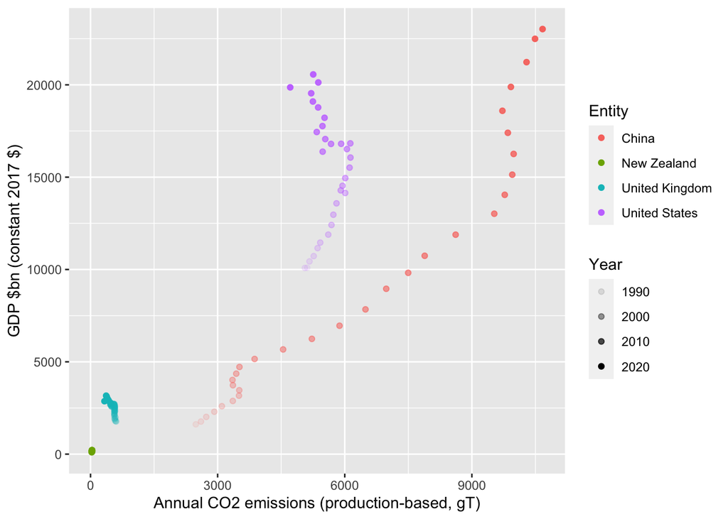

Figure 1: UK GDP vs production emissions over time.

```r
plotDT <- dt_abs[Entity %in% entities_of_interest]

ggplot2::ggplot(plotDT, aes(y = as.numeric(`GDP, PPP (constant 2017 international $)`)/1000000000,
                            x = as.numeric(`Annual CO2 emissions`)/1000000,
                            colour = Entity,
                            alpha = Year)) +
  geom_point() +
  labs(x = "Annual CO2 emissions (production-based, gT)",
       y = "GDP $bn (constant 2017 $)")
```

Next we’ll try consumption emissions.

Note that 2020 consumption-based emissions data is missing so you don’t see the downtick

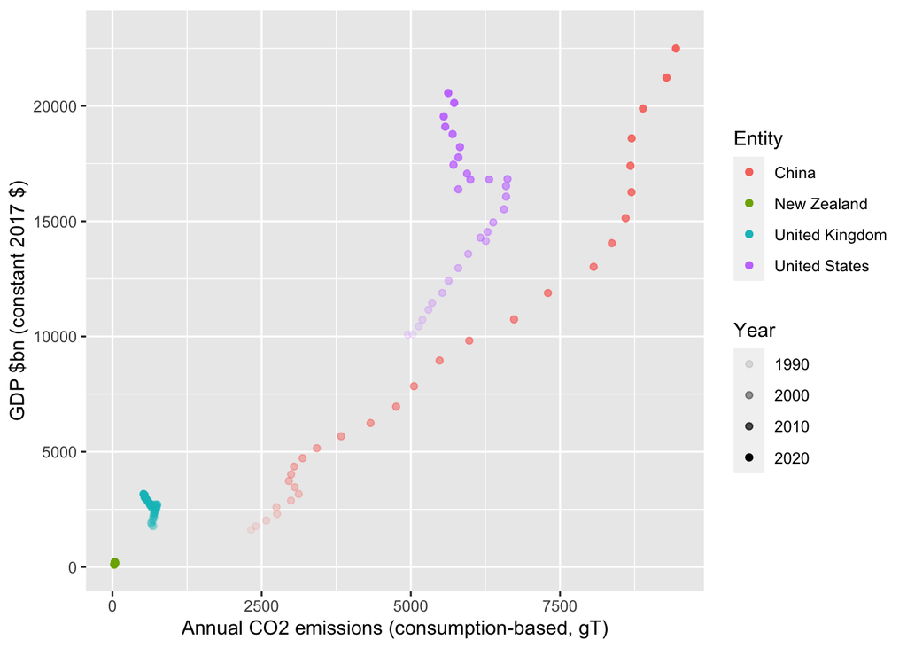

Figure 2: UK GDP vs consumption emissions over time.

```r
plotDT <- dt_abs[Entity %in% entities_of_interest]

ggplot2::ggplot(plotDT, aes(y = as.numeric(`GDP, PPP (constant 2017 international $)`)/1000000000,
                            x = as.numeric(`Annual consumption-based CO2 emissions`)/1000000,
                            colour = Entity,
                            alpha = Year)) +
  geom_point() +
  labs(x = "Annual CO2 emissions (consumption-based, gT)",
       y = "GDP $bn (constant 2017 $)")
```

# Per capita GDP & emissions

Since we’ll be dividing everything pairwise by the same denominator, nothing much should change… but the plots should be much clearer as we’ve removed the affect of population size

First we’ll try production emissions.

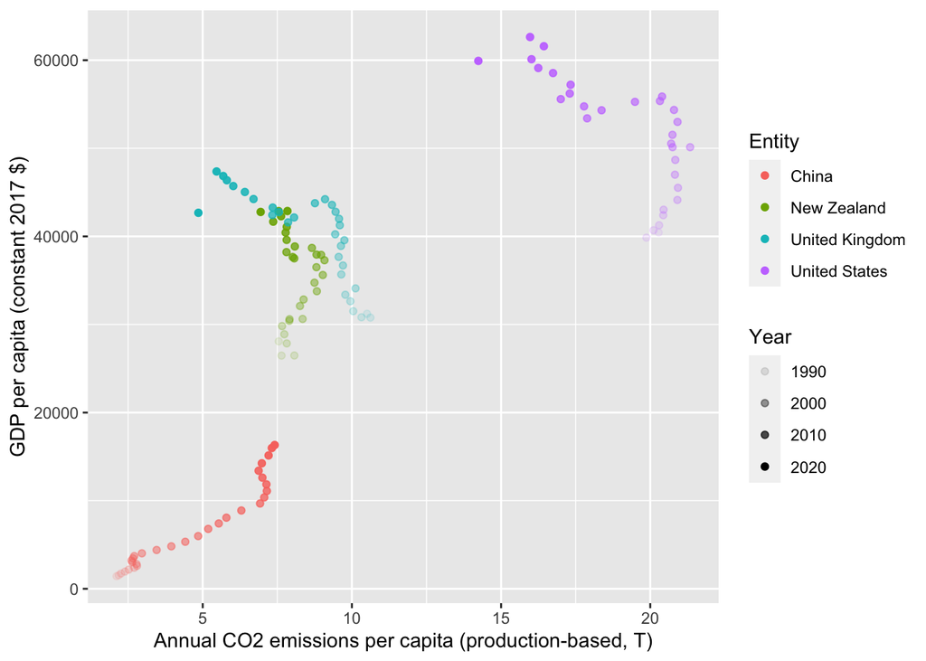

Figure 3: UK GDP vs production emissions over time.

```r
plotDT <- dt_pc[Entity %in% entities_of_interest]

ggplot2::ggplot(plotDT, aes(y = as.numeric(`GDP per capita, PPP (constant 2017 international $)`),
                            x = as.numeric(`Annual CO2 emissions (per capita)`),
                            colour = Entity,
                            alpha = Year)) +
  geom_point() +
  labs(x = "Annual CO2 emissions per capita (production-based, T)",
       y = "GDP per capita (constant 2017 $)")
```

Next we’ll try consumption emissions.

Note that 2020 consumption-based emissions data is missing so you don’t see the downtick

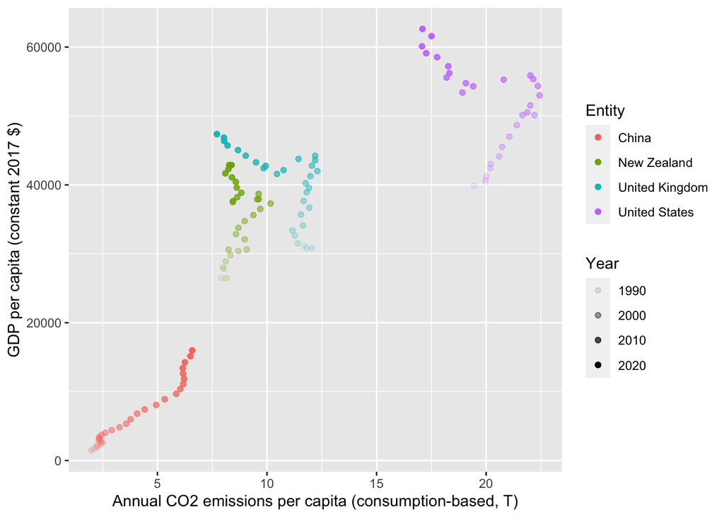

Figure 4: UK GDP vs consumption emissions over time.

```r
plotDT <- dt_pc[Entity %in% entities_of_interest]

ggplot2::ggplot(plotDT, aes(y = as.numeric(`GDP per capita, PPP (constant 2017 international $)`),
                            x = as.numeric(`Annual consumption-based CO2 emissions (per capita)`),
                            colour = Entity,
                            alpha = Year)) +
  geom_point() +
  labs(x = "Annual CO2 emissions per capita (consumption-based, T)",
       y = "GDP per capita (constant 2017 $)")
```

# Efficiency

How about looking at efficency gC02e per $ GDP?

Following https://timjackson.org.uk/earth-vs-growth/ …

```r
dt_abs[, `Emissions intensity` := `Annual CO2 emissions`/`GDP, PPP (constant 2017 international $)`*1000*1000]

entities_of_interest <- c("United Kingdom", "United States", "World", "New Zealand", "China")
```

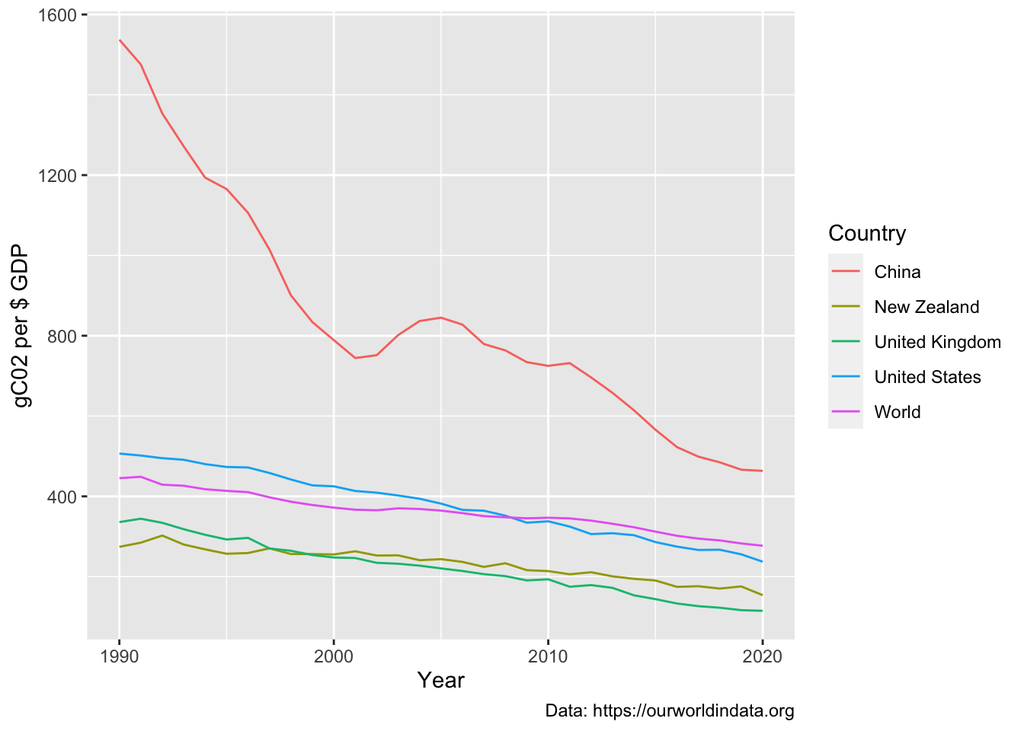

```r
plotDT <- dt_abs[Entity %in% entities_of_interest]

ggplot2::ggplot(plotDT, aes(Year, `Emissions intensity`, colour = Entity)) +
  geom_line() +
  labs(y = "gC02 per $ GDP",
       colour = "Country",
       caption = "Data: https://ourworldindata.org")
```

Regardless of whether that aligns with [science-based targets](https://sciencebasedtargets.org/how-it-works) (i.e. absolute zero by 2044) … what happens if the economy grows … by say 2-3% per year? … would that force total emissions up (fixed intensity) or result in efficiency gains (lower intensity)?

```r
dt_abs[, `Emissions intensity (consumption-based)` := `Annual consumption-based CO2 emissions`/`GDP, PPP (constant 2017 international $)`*1000*1000]
```

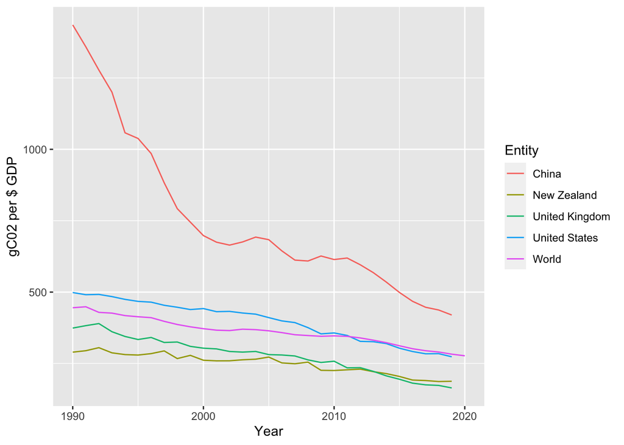

```r
plotDT <- dt_abs[Entity %in% entities_of_interest]

ggplot2::ggplot(plotDT, aes(Year, `Emissions intensity (consumption-based)`, colour = Entity)) +
  geom_line() +
  labs(y = "gC02 per $ GDP")
```

# Whom do we love?

[quarto](https://quarto.org/)

[data.table](https://www.rdocumentation.org/packages/data.table/versions/1.14.2)

[ggplot2](https://www.rdocumentation.org/packages/ggplot2/versions/3.3.6)

[here](https://www.rdocumentation.org/packages/here/versions/1.0.1)

[skimr](https://www.rdocumentation.org/packages/skimr/versions/2.1.4)

# Data descriptions

Check

Skim the absolute data:

```r
skimr::skim(dt_abs)
```

Data summary

| Name | dt_abs |
| --- | --- |
| Number of rows | 7795 |
| Number of columns | 8 |
| Key | NULL |
| _______________________ |  |
| Column type frequency: |  |
| character | 4 |
| numeric | 4 |
| ________________________ |  |
| Group variables | None |

**Variable type: character**

| skim_variable | n_missing | complete_rate | min | max | empty | n_unique | whitespace |
| --- | --- | --- | --- | --- | --- | --- | --- |
| Entity | 0 | 1.00 | 4 | 32 | 0 | 255 | 0 |
| Code | 0 | 1.00 | 0 | 8 | 931 | 225 | 0 |
| Annual CO2 emissions | 479 | 0.94 | 1 | 21 | 0 | 6137 | 0 |
| GDP, PPP (constant 2017 international $) | 1626 | 0.79 | 1 | 21 | 0 | 6162 | 0 |

**Variable type: numeric**

| skim_variable | n_missing | complete_rate | mean | sd | p0 | p25 | p50 | p75 | p100 | hist |
| --- | --- | --- | --- | --- | --- | --- | --- | --- | --- | --- |
| Year | 0 | 1.00 | 2005.06 | 8.930000e+00 | 1990.00 | 1997.00 | 2005.00 | 2013.00 | 2.02000e+03 | ▇▇▇▇▇ |
| Annual consumption-based CO2 emissions | 3730 | 0.52 | 976326173.39 | 3.366486e+09 | 197201.67 | 10759532.52 | 59975058.69 | 290854945.27 | 3.67025e+10 | ▇▁▁▁▁ |
| Emissions intensity | 2105 | 0.73 | 263.56 | 2.409400e+02 | 9.15 | 122.67 | 196.73 | 309.26 | 2.30112e+03 | ▇▁▁▁▁ |
| Emissions intensity (consumption-based) | 4295 | 0.45 | 291.92 | 1.686800e+02 | 4.19 | 179.06 | 251.82 | 365.36 | 1.82195e+03 | ▇▂▁▁▁ |

Skim the per capita data

```r
skimr::skim(dt_pc)
```

Data summary

| Name | dt_pc |
| --- | --- |
| Number of rows | 7745 |
| Number of columns | 6 |
| Key | NULL |
| _______________________ |  |
| Column type frequency: |  |
| character | 2 |
| numeric | 4 |
| ________________________ |  |
| Group variables | None |

**Variable type: character**

| skim_variable | n_missing | complete_rate | min | max | empty | n_unique | whitespace |
| --- | --- | --- | --- | --- | --- | --- | --- |
| Entity | 0 | 1 | 4 | 32 | 0 | 252 | 0 |
| Code | 0 | 1 | 0 | 8 | 899 | 224 | 0 |

**Variable type: numeric**

| skim_variable | n_missing | complete_rate | mean | sd | p0 | p25 | p50 | p75 | p100 | hist |
| --- | --- | --- | --- | --- | --- | --- | --- | --- | --- | --- |
| Year | 0 | 1.00 | 2005.07 | 8.93 | 1990.00 | 1997.00 | 2005.00 | 2013.00 | 2020.00 | ▇▇▇▇▇ |
| GDP per capita, PPP (constant 2017 international $) | 1579 | 0.80 | 17879.29 | 20132.68 | 436.72 | 3678.83 | 10365.78 | 25832.03 | 161971.47 | ▇▂▁▁▁ |
| Annual consumption-based CO2 emissions (per capita) | 3680 | 0.52 | 6.53 | 6.92 | 0.05 | 1.19 | 4.30 | 9.89 | 57.79 | ▇▂▁▁▁ |
| Annual CO2 emissions (per capita) | 492 | 0.94 | 5.11 | 6.44 | 0.02 | 0.77 | 2.97 | 7.42 | 68.72 | ▇▁▁▁▁ |

```r
# hidden chunk
```